# 概要

機械学習

[川田恵介](https://github.com/tetokawata/TargetML)

keisukekawata@iss.u-tokyo.ac.jp

東京大学

2025-09-11

# 概念整理

## データ分析法

- 過去の経験や事例、歴史（データ）から学ぶ方法
- 意思決定に役立つ情報提供を目指す
  - 各顧客は、どのようなサービスを好みのか?
  - 事業全体で価格を上げると、どの程度需要が下がるのか?
  - どのような事業領域が伸びているのか?

## 現状

- 学術/実務機関から高い関心<sup>1</sup>
- 参考文献: 事例紹介 $+$ 考察
  - [予測マシンの世紀 AIが駆動する新たな経済](https://www.amazon.co.jp/gp/product/B07NJ6YY9G/ref=ppx_yo_dt_b_d_asin_title_o02?ie=UTF8&psc=1)
[^1]: [Amazon](https://www.amazon.science/tag/causal-inference), [Cyber Agent](https://www.cyberagent.co.jp/techinfo/ai/tech/detail/id=24953), [Microsoft](https://www.microsoft.com/en-us/research/group/alice/), [Mizuho](https://www.mizuho-fg.co.jp/dx/articles/ft-icml/index.html), [Netflix](https://research.netflix.com/research-area/experimentation-and-causal-inference), [Uber](https://www.uber.com/en-JP/blog/causal-inference-at-uber/)

## 近年の発展

- 機械学習: 予測研究への応用がメイン
  - 機械学習 $+$ 計量経済学/医療統計等を身につけることで、因果効果や格差研究等への応用も可能に
    - 学部/大学院レベルの教科書<sup>1</sup>が書かれる段階になっている
[^2]: [Applied Causal Inference Powered by ML and AI](https://causalml-book.org/)

## 到達目標

- 自身でデータ分析を行うための入門
  - データ分析の不完全性への対処に焦点
- データ分析の結果を意思決定に活用するための必要知識の取得
- エントリーシートなどに、“AI/機械学習を用いた不動産市場についての、予測・因果モデルを作成経験した経験あり”と書けるようにする

# Get started

## 一般的課題

- データ分析を含む事例分析の共通課題
  - 独立した分析チームに**同じ市場/社会**について、事例収集とデータ分析を依頼したとしても、同じ結論に到達し得ない
    - 誰がやっても、「水は100度で沸騰する」という結論に到達する理科の実験とは対照的

## データ

- 現代の分析では、大量の事例が含まれるデータを利用する機会が多い
  - 実習では、11311 の中古マンション取引事例
    - 全ての事例を人間が直接認識することは不可能

## “個別事例分析”

- 特徴的な事例を研究者が選別する
- 最高価格で取引されている物件は

| Price | District | Size |
| --- | --- | --- |
| 1,400 | 杉並 | 105 |

- “杉並区の105平米の物件の取引価格は1億4000万円” と主張できるか?

## “個別事例分析”の問題点

- 全く同じ属性を持つ物件は、他にも存在する

| Price | District | Size |
| --- | --- | --- |
| 85 | 杉並 | 105 |
| 160 | 杉並 | 105 |
| 93 | 杉並 | 105 |
| 110 | 杉並 | 105 |
| 1,400 | 杉並 | 105 |

- データから観察できない要因で、先の事例は大幅に上振れたのでは?

## 要約計画

- データにおいて観察できない要因の影響を減じるために、
  - 何らかの要約を用いて、集団の”傾向”を論じる
    - 典型的な事例の報告、研究者の所見/印象、平均値、中央値、分散
- 恣意的分析を避けるために、データを見る前に、要約計画を立てることが重要
  - 平均などの”自動計算”できる方法が有効

## 実例: 平均取引価格

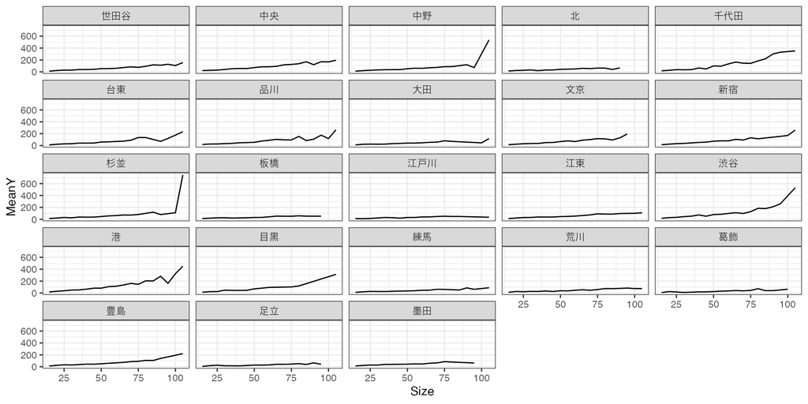

## 実例

- 1事例のみで平均値を計算している組み合わせが24組存在 (例: 千代田区95平米)
  - 上振れ/下振れの恐れが高い
- さらなる要約が有益

## 伝統的アプローチ

1. **分析者**が、サブグループ (モデル) を定義する
- 例: 練馬区かどうか $\times$ 部屋の広さが55平米以下かどうか
2. サブグループの平均値を計算
- 集計により偶然の上振れ/下振れの影響を軽減する

## 伝統的アプローチ

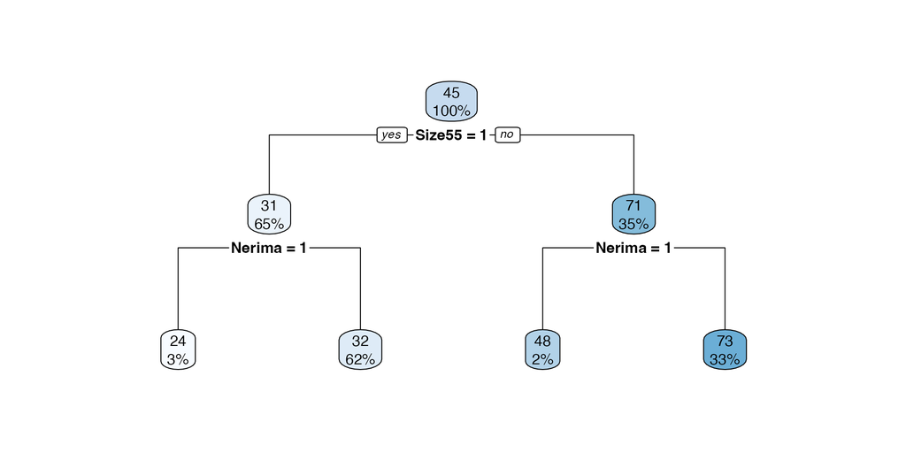

## 伝統的アプローチの利点

- データの偶然の上振れ、下振れを定量化できる (信頼区間)
  - 一定の確率で、“無限大”の事例数で計算された平均値(母平均)を含む区間
  - 偶然生じた傾向か否かを区別でき、重大な意思決定への活用において、特に望ましい性質

## 例: 信頼区間

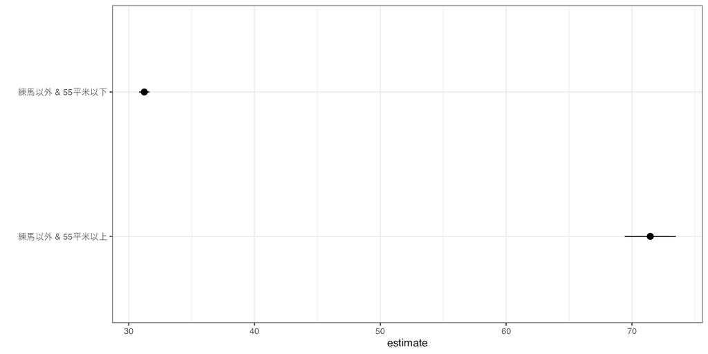

## モデルの設定

- 事例の要約方法(モデル化)が属人的で、不透明
  - 推定結果を大きく左右しうる
    - 多くの教科書で直接的な言及を避けてきた問題
      - 「理論や背景をしっかり踏まえて、適切なモデル化を行うべし」以上の提案が難しい
    - 機械学習の適切な活用が有効

## 付論: モデルの設定

- モデルを色々試すことで、分析者にとって”望ましい結果” (例: 明確な因果効果、存在しない格差の存在”証明”など)を、“捏造”できる
  - Cherry-pick/p-huckなどと呼ばれる
- 無実の証明が難しい
  - 疑われないようにするために、“複雑な分析”を避ける傾向
    - 例: どのような背景属性の組み合わさると、改装は大きな効果を持つか?

## データ主導のモデリング

- 決定木アルゴリズム: **データ**に最も適合するように、サブグループを定義する
  - よりデータ主導
  - 明確な基準(“データへの適合”)のもとで、要約方法を決定
- 機械学習の得意分野

## 例

- 最大４グループに分けることは前提に、平均二乗誤差
  $$(Y - モデルの予測値)^2のデータ上での平均値$$
  を可能な限り削減するようにグループ分けを行う
  - 近似的に削減する (Greedy-algorithm)

## 実例

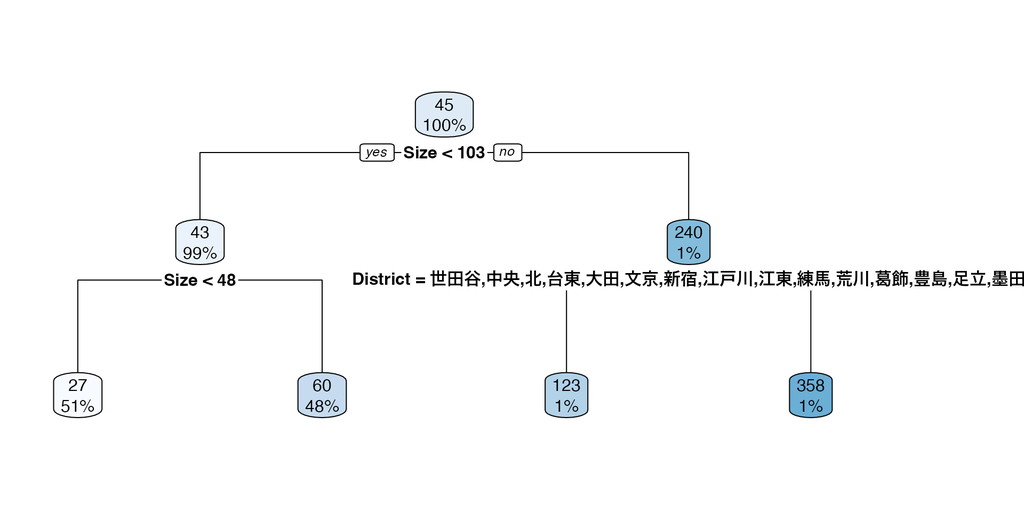

## 例. 複雑なモデル

- 機械学習を用いれば、より複雑なモデルも容易に生成できる
- 例. 最大32グループに分ける

## 複雑なモデル

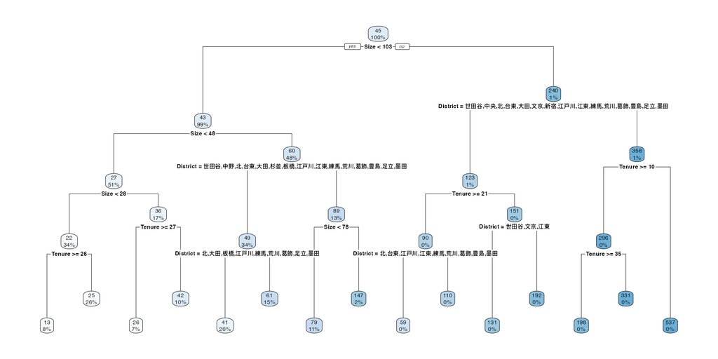

# Takeaway

## 伝統的アプローチの利点と課題

- **利点:** 研究者が設定するシンプルなモデルについて、データの偏りの影響を評価しながら、推定できる
  - 無限大の事例数で推定した場合について、概ね正しい推測ができる(信頼区間)
- **課題:** 予測性能は、研究者が設定したモデルに強く依存する

## 本講義の提案

- 機械学習と伝統的な統計学/計量経済学/医療統計等の手法と”併用”する

## 予習資料

- 入門的な統計学 $+$ R

  [Statistical Inference via Data Science](https://moderndive.com/v2/thinking-with-data.html)
- ガッチリ機械学習
  - [Introduction to Statistical Learning (Trevor Hastie, Robert Tibshirani, Jerome Friedman)](https://www.statlearning.com/)

# R

## R VS Python

- Pythonと並ぶ、データ分析の人気言語
  - 高い透明性と拡張性、再現可能性、無料、AI活用
  - 多様な統合開発環境(IDE)

## 準備

- [Posit cloudへの登録](https://youtu.be/yF6NxxvpzjE)
  - クラウド環境でRを使用できる
  - ただし時間制限あり
- [関心がある人は、自身のPCへRstudioをインストール](https://youtu.be/fDlXx8e5W78)
  - 時間無制限

## Example code

- コードを実行する際には、(慣れるまでは)、以下の手順を徹底
1. ctr + a を押し、全ての行を選択する
2. ctr + enterを押し、実行する

## Errorが出たら

- 「errorは必ず起きる」、という心構えをもつ
- 再現性の確認： 全ての行を再度実行
  - コード実行しわすれ、がエラーの原因となることが多い
- よくあるミス (大文字/小文字の区別、 コンマ)を確認
  - 極力予測変換を活用し、タイポを減らす
- 解決できない場合は、コード全体をチェット欄にコピペしてください